# 04.Ciona_prot_LF.MS

Author

Andrea Mariossi

Published

December 1, 2023

# 1 Absolute LF-MS on unfertilised egg

Comparing abs protein eggs (LF-MS) and relative protein eggs (TMTcPro-MS). The data are normalized using Theil-Sen estimator which is robust against outliers.

I will then compare to relative proteomics (TMTc) and RNA (salmon counts)

1. Compare egg absolute vs relative
2. Compare egg protein vs RNA

#### 1.0.0.1 Loading libraries

#### 1.0.0.2 Functions and misc

```r
rm(list=ls())

###############################
#### Directories
###############################

directory_figures <- c("/Users/mariossi/Library/CloudStorage/Dropbox-Princeton/Papers/Proteomics_ciona/c.data_analysis/")

directory_save <- c("/Users/mariossi/Library/CloudStorage/Dropbox-Princeton/Papers/Proteomics_ciona/c.data_analysis/")

# Vector with stages in develpmental order
ciona_stages <- c("unfE","fertE","cell16","iniG","latN","midTII","latTII","larva")
ciona_stages_beautify <- c("unfertilised","1-cell","16-cell","110-cell","late neurula","mid tailbud","late tailbud","larva")

###############################
#### Color palette
###############################

ciona_stages_palette <- c("#009392FF", "#39B185FF", "#9CCB86FF", "#E9E29CFF", "#EEB479FF", "#E88471FF", "#CF597EFF","#D82526FF")

ciona_cluster_palette <- c("#88A0DCFF", "#381A61FF", "#7C4B73FF", "#ED968CFF", "#AB3329FF", "#E78429FF", "#F9D14AFF", "#7FA074FF") # > paletteer::paletteer_d("MetBrewer::Archambault") + MetBrewer::Cassatt2" - Colorblind-Friendly

theme_personalised <- theme_pubr(base_family = "Avenir") +
                      theme(panel.background=element_blank(),
                            panel.border=element_blank(),
                            panel.grid.major=element_blank(),
                            panel.grid.minor=element_blank(),
                            plot.background=element_blank())
```

#### 1.0.0.3 Loading data, annotation & descriptive statistics

```r
###############################
#### Loading the data
###############################

egg.abs.df <-  as_tibble(
  read_excel(paste0(directory_figures,"LF_Egg_UPS2_ky21.xlsx"),
             sheet = "absolute_unfertilised_egg",
             range = cell_cols("A:L"),
             trim_ws = T))

glimpse(egg.abs.df)
```

```
Rows: 6,102
Columns: 12
$ protein_id                  <chr> "KY21.Chr1.2009.v1.ND1-1", "KY21.Chr10.753.v1.nonSL4-3", "KY21.Chr11.687.v1.nonSL18-1", "KY21.Chr3.1499.v1.nonSL10-1", "KY21.Chr11.1236.v1.SL1-1", "KY21.Chr9.158.v1.nonSL8-1", "KY21.Chr11.637.v2.nonSL7-1", "KY21.Chr14.174.v1.nonSL6-1", "KY21.Chr10.268.v2.SL3-1", "…
$ gene_id                     <chr> "KY21.Chr1.2009", "KY21.Chr10.753", "KY21.Chr11.687", "KY21.Chr3.1499", "KY21.Chr11.1236", "KY21.Chr9.158", "KY21.Chr11.637", "KY21.Chr14.174", "KY21.Chr10.268", "KY21.Chr1.2019", "KY21.Chr3.341", "KY21.Chr8.1148", "KY21.Chr6.684", "KY21.Chr10.215", "KY21.Chr7.957…
$ `#_peps`                    <dbl> 208, 35, 20, 30, 5, 10, 23, 23, 7, 25, 26, 12, 15, 9, 4, 6, 26, 36, 23, 36, 33, 40, 36, 20, 25, 10, 19, 14, 10, 21, 45, 5, 28, 9, 14, 7, 7, 7, 7, 22, 8, 13, 11, 7, 11, 11, 3, 8, 5, 11, 12, 9, 6, 13, 7, 8, 8, 18, 23, 17, 32, 11, 6, 17, 9, 26, 18, 20, 15, 23, 7, 30,…
$ linear_area                 <dbl> 41737748545, 5872163409, 5707133303, 5667885776, 5540562478, 5034059951, 4104099849, 3987047728, 3689476717, 3628725273, 3303175782, 2974406132, 2962103295, 2949296385, 2208516525, 2207407050, 2132339446, 1796017240, 1764740314, 1574926189, 1562954123, 1560581064,…
$ log_area                    <dbl> 10.620529, 9.768798, 9.756418, 9.753421, 9.743554, 9.701918, 9.613218, 9.600651, 9.566965, 9.559754, 9.518932, 9.473400, 9.471600, 9.469718, 9.344101, 9.343882, 9.328856, 9.254311, 9.246681, 9.197260, 9.193946, 9.193286, 9.164623, 9.158595, 9.154275, 9.124356, 9.1…
$ log_amount                  <dbl> 6.004111, 5.263733, 5.252971, 5.250366, 5.241789, 5.205597, 5.128493, 5.117569, 5.088286, 5.082019, 5.046533, 5.006954, 5.005390, 5.003754, 4.894559, 4.894369, 4.881308, 4.816508, 4.809876, 4.766916, 4.764035, 4.763462, 4.738546, 4.733306, 4.729551, 4.703543, 4.69…
$ linearized_amount           <dbl> 1009510.313, 183540.846, 179048.693, 177977.883, 174497.343, 160544.949, 134428.894, 131089.845, 122542.430, 120786.530, 111309.724, 101614.184, 101248.734, 100868.100, 78443.865, 78409.608, 76086.511, 65540.196, 64546.921, 58467.703, 58081.165, 58004.501, 54770.3…
$ `concentration_(um)`        <dbl> 1202.871984, 218.696272, 213.343691, 212.067779, 207.920575, 191.295739, 160.177414, 156.198802, 146.014215, 143.921990, 132.629996, 121.077372, 120.641924, 120.188383, 93.469008, 93.428190, 90.660126, 78.093770, 76.910242, 69.666611, 69.206035, 69.114687, 65.2610…
$ normalised_OSL              <dbl> 230.4895244, 41.9057060, 40.8800658, 40.6355806, 39.8409100, 36.6553254, 30.6925561, 29.9301905, 27.9786605, 27.5777568, 25.4140300, 23.2003623, 23.1169234, 23.0300177, 17.9101579, 17.9023365, 17.3719312, 14.9640162, 14.7372333, 13.3492377, 13.2609840, 13.2434802,…
$ normalised_removed_outliers <dbl> 169.0584092, 35.3016395, 34.5070151, 34.3173602, 33.7002658, 31.2162559, 26.5179198, 25.9121308, 24.3556093, 24.0347786, 22.2965144, 20.5056213, 20.4378540, 20.3672500, 16.1661546, 16.1596682, 15.7192468, 13.7055063, 13.5145492, 12.3404612, 12.2654831, 12.2506075,…
$ normalised_siegel           <dbl> 182.2948993, 36.8539898, 36.0074891, 35.8055119, 35.1484836, 32.5062866, 27.5209241, 26.8793907, 25.2324648, 24.8932656, 23.0571389, 21.1685152, 21.0971149, 21.0227309, 16.6070150, 16.6002140, 16.1385736, 14.0313342, 13.8318289, 12.6064938, 12.5283224, 12.5128145,…
$ normalised_theil            <dbl> 179.8499343, 36.5731349, 35.7361252, 35.5364020, 34.8866774, 32.2733935, 27.3404087, 26.7053894, 25.0749286, 24.7390730, 22.9207484, 21.0498817, 20.9791410, 20.9054433, 16.5286248, 16.5218808, 16.0640774, 13.9737215, 13.7757577, 12.5596544, 12.4820578, 12.4666636,…
```

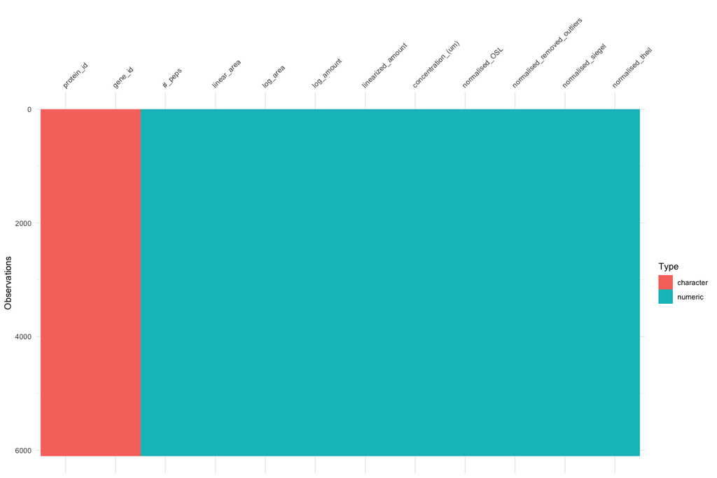

```r
vis_dat(egg.abs.df)
```

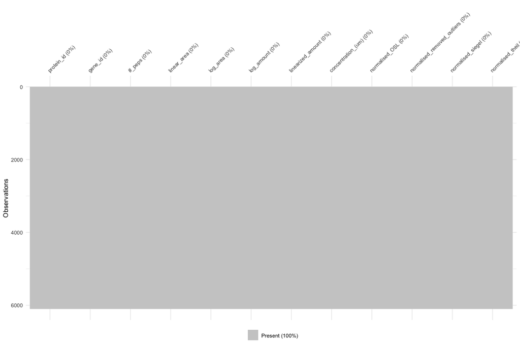

```r
vis_miss(egg.abs.df)
```

```r
ciona_prot.df <- as_tibble(read_delim(paste0(directory_figures,"ciona_proteome_normToChan.tsv")),col_names = T,trim_ws = T)

# TPM => all no filtering
ciona_rna.df <- as_tibble(read_delim(paste0(directory_figures,"ciona_rna_tpm_meanRep.tsv")),col_names = T,trim_ws = T)


# dropping not needed columns
egg.abs <- egg.abs.df %>% dplyr::select(1:3,12)
egg.rel <-  ciona_prot.df %>% dplyr::select(1:6)

###############################
#### annotation with TF and signalling molecules
###############################
# loading Annotation table - TFs, signalling molecules, genes names and symbols etc. The file contains informations from KY21 genome (gfff3), Ghost database, Aniseed and Selex paper

# Load TFs and signalling from Ghost database and Nitta et al. 2019
annRef <- read_excel("/Users/mariossi/Library/CloudStorage/Dropbox-Princeton/Papers/Proteomics_ciona/a.reference_annotation/KY21_geneAnnotation_ghost&nitta2019.xlsx",trim_ws = T,col_names = T,sheet = "tf_and_signal") %>%
  rename_all(tolower) |>
  mutate(family = str_to_lower(family))

keyTF <- read_excel("/Users/mariossi/Library/CloudStorage/Dropbox-Princeton/Papers/Proteomics_ciona/a.reference_annotation/KY21_geneAnnotation_ghost&nitta2019.xlsx",trim_ws = T,col_names = T,sheet = "KY_TFs") %>%
  rename_all(tolower)

keySMs <- read_excel("/Users/mariossi/Library/CloudStorage/Dropbox-Princeton/Papers/Proteomics_ciona/a.reference_annotation/KY21_geneAnnotation_ghost&nitta2019.xlsx",trim_ws = T,col_names = T,sheet = "KY_signaling.molecules") %>%
  rename_all(tolower)

# tissue markers
tissueMarkers <- read_excel("/Users/mariossi/Library/CloudStorage/Dropbox-Princeton/Papers/Proteomics_ciona/a.reference_annotation/KY21_geneAnnotation_ghost&nitta2019.xlsx",trim_ws = T,col_names = T,sheet = "tissue_marker")

# tissue markers
kinases_phosphatases.df <- read_excel("/Users/mariossi/Library/CloudStorage/Dropbox-Princeton/Papers/Proteomics_ciona/a.reference_annotation/KY21_geneAnnotation_ghost&nitta2019.xlsx",trim_ws = T,col_names = T,sheet = "kinases_&_phosphatases") |>
  mutate(family = str_to_lower(family))
```

## 1.1 QC LF-MS

- 1 % Protein 62815 unique, 157906 total peptide, 7347 total protein Protein FDR: 16.14 % (593 protein(s)) One Hit Wonders:1722
- 0.1 % Protein 62341 unique, 157410 total peptide, 6873 total protein Protein FDR: 9.98 % (343 protein(s)) One Hit Wonders:1248
- 0.02 % 61749 unique, 156688 total peptide, 6281 total protein Protein FDR: 1.97 % (62 protein(s)) One Hit Wonders:656
- 0.01 % 61570 unique, 156429 total peptide, 6107 total protein Protein FDR: 0.98 % (30 protein(s)) One Hit Wonders:487
- 0.001 % Protein 60952 unique, 155559 total peptide, 5619 total protein Protein FDR: 0.07 % (2 protein(s)) One Hit Wonders:126
- 0.0001 % 59569 unique, 153500 total peptide, 4934 total protein Protein FDR: 0.00 % (0 protein(s)) One Hit Wonders:1

```r
###############################
#### Loading the data
###############################

# LF_fdr_1perc.df <-  as_tibble(
                              # read_excel("Desktop/LF_fdr.xlsx",
                              #            sheet = "1%_fdr",
                              #            trim_ws = T)
                              # )

LF_fdr_2perc.df <-  as_tibble(
  read_excel("/Users/mariossi/Library/CloudStorage/Dropbox-Princeton/Papers/Proteomics_ciona/b.raw_data/proteome/LF_fdr.xlsx",
             sheet = "2%_fdr",
             trim_ws = T)
)

# LF_fdr_1perc.df |> filter(!grepl("^#", reference)) #6,077

LF_fdr_2perc.df |> filter(!grepl("^#", reference)) #6,219
```

```
# A tibble: 6,219 × 9
   Unique Total reference                     AVG `Gene Symbol` `MWT(kDa)` Length Coverage `Coverage %`
    <dbl> <dbl> <chr>                       <dbl> <chr>              <dbl>  <dbl>    <dbl>        <dbl>
 1    386  9289 KY21.Chr1.2009.v1.ND1-1      3.22 <NA>                475.   4238     2383        0.562
 2    229  1000 KY21.Chr8.1053.v1.ND1-1      3.11 <NA>                622.   5602     2129        0.38
 3    193   430 KY21.Chr3.173.v1.ND1-1       2.91 <NA>                529.   4602     1760        0.382
 4    115   252 KY21.Chr3.762.v1.SL2-1       3.14 <NA>                279.   2591     1213        0.468
 5    101   332 KY21.Chr11.334.v1.SL1-1      3.36 <NA>                229.   1976      892        0.451
 6     98   202 KY21.Chr12.733.v1.nonSL1-1   3.08 <NA>                663.   6206     1192        0.192
 7     95   228 KY21.Chr14.883.v1.nonSL3-1   2.76 <NA>                247.   2228      885        0.397
 8     94   180 KY21.Chr9.653.v2.nonSL6-1    2.92 <NA>                406.   3619     1183        0.327
 9     94   172 KY21.Chr10.1084.v1.nonSL2-2  3.07 <NA>                283.   2470     1048        0.424
10     92   169 KY21.Chr4.322.v1.SL2-1       2.84 <NA>                485.   4394     1058        0.241
# ℹ 6,209 more rows
```

```r
LF_fdr_2perc.df |>
  filter(!grepl("^#", reference)) |>
  summarise(median=median(`Coverage %`),
         mean=mean(`Coverage %`)) |>
  round(digits = 2)
```

```
# A tibble: 1 × 2
  median  mean
   <dbl> <dbl>
1   0.18  0.21
```

```r
prot_coverage <- LF_fdr_2perc.df |>
  filter(!grepl("^#", reference)) |>
  ggplot(aes(x = `Coverage %`)) +
  geom_density(linewidth = 1.5) +
  geom_vline(xintercept = 0.21, linetype = "dashed", color = "black", size = 1.1) +  # Adding a vertical line
  annotate("text", x = 0.3, y = 0.6, label = "mean: 21%", angle = 0, size=7, color = "black") +  # Adding annotation

  labs(x = "Seqeunce Coverage %", y = "Density") +
  scale_x_continuous(labels = scales::percent,limits = c(0,1)) +
  coord_flip() +
  theme_personalised

# Data points FDR
data<- data.frame(
  fdr = c(1, 0.1, 0.02, 0.01, 0.001, 0.0001),
  values = c(6754, 6530, 6219, 6077, 5617, 4934)
)

#https://stackoverflow.com/questions/11053899/how-to-get-a-reversed-log10-scale-in-ggplot2

# Calculating the maximum value
max_value <- max(data$values)

# Transforming Values to percentages of the maximum value
data$values_Percentage <- (data$values / max_value)

# Create the plot
prot_FDR <- ggplot(data, aes(x = (fdr), y = values_Percentage)) +
  geom_point(size=2) +
  geom_line(size=1) +
  scale_x_continuous(
    trans  = compose_trans("log10", "reverse"),
    breaks = c(1, 0.1, 0.02, 0.01, 0.001, 0.0001),
    labels = c(1, 0.1, 0.02, 0.01, 0.001, 0.0001)
  ) +
  geom_vline(xintercept = 0.02, linetype = "dashed", color = "black", size = 1.1) +  # Adding a vertical line
  annotate("text", x = 0.02, y = 1, label = "6,219 proteins with isoform", angle = 0, hjust = -0.1,size=7, color = "black") +  # Adding annotation
  scale_y_continuous(labels = scales::percent,limits = c(0.7,1)) +
  labs(x = "FDR [%]",
       y = "Protein identification [%]") +
  theme_personalised

LF_MS_QC <- prot_coverage + prot_FDR & theme(text = element_text(size=14), axis.title = element_text(size = 22))

cairo_pdf("LF_MS_QC.pdf", width=8.5, height=5.6)
print(LF_MS_QC)
invisible(dev.off())
```

## 1.2 Overlapping absolute with relative MS in unfE

All the analysis are on gene-level = protein level eg all isoforms are collapsed

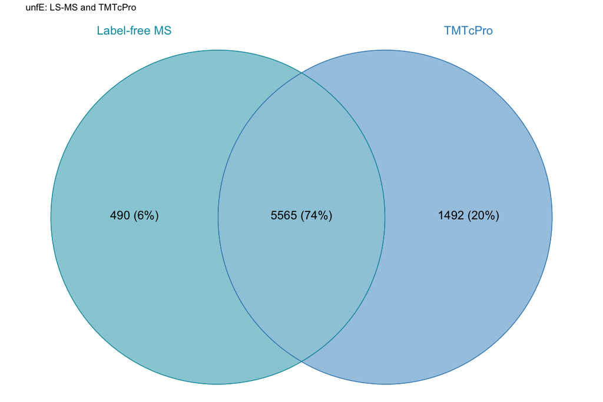

```r
###############################
#### absolute vs relative unfE
###############################

egg.abs_gene = unique(egg.abs$gene_id)
egg.rel_gene = unique(egg.rel$protein_id_gene)

egg.abs_protein = unique(egg.abs$protein_id)
egg.rel_protein = unique(egg.rel$protein_id_transcript)

differences_gene <- setdiff(egg.abs_gene, egg.rel_gene) #490 eg protein only detected by abs
common_elements_gene <- intersect(egg.abs_gene, egg.rel_gene) #5565 common protein between the two MS methods

x_gene <- list(`Label-free MS`=egg.abs_gene, `TMTcPro`=egg.rel_gene)
venn_gene <- Venn(x_gene)
data_gene <- process_data(venn_gene)

colorGroups <- c("Label-free" = '#009baf', "TMTcPro" = '#398dc4') # vector for colors
colfunc <- colorRampPalette(colorGroups) # use colorRampPalette to create function that interpolates colors
col <- colfunc(3) # call function and create vector of 3 colors

venn_overlap_egg.abs.rel_gene <-
 ggplot() +
  geom_sf(aes(fill = name), data = venn_region(data_gene)) +  # 1. region count layer
  geom_sf(aes(color = name), data = venn_setedge(data_gene)) +  # 2. set edge layer
  # geom_sf(size = 4, lty = "dashed", color = "black", data = venn_setedge(data)) +
  geom_sf_text(aes(label = name), data = venn_setlabel(data_gene), size = 6,color = colorGroups ) +  # 3. set label layer
  geom_sf_text(aes(label = paste0(count," (", scales::percent(count/sum(count), accuracy = 2), ")")), data = venn_region(data_gene),size = 6) +
  # geom_sf_label(aes(label = paste0(count," (", scales::percent(count/sum(count), accuracy = 2), ")")), data = venn_region(data_gene),size = 6) +  # 4. region label layer
  scale_fill_manual(values = alpha(col, .5)) +
  scale_color_manual(values = c("#009baf",'#398dc4')) +
  labs(title = "unfE: LS-MS and TMTcPro") +
  theme_void(base_family = "Arial") +
  theme(legend.position = "none")

venn_overlap_egg.abs.rel_gene
```

```r
cairo_pdf("plot_overlap_protMS.pdf", width=8.5, height=5.6)
print(venn_overlap_egg.abs.rel_gene)
invisible(dev.off())
```

## 1.3 Overlapping absolute protein with RNA in unfE

```r
###############################
#### Venn diagram
###############################

rna_egg <- ciona_rna.df %>% dplyr::select(1,2) %>% filter(unfE >=5) # drop low expression genes 8,690

# overlap_egg.abs.rna  <-  inner_join(egg.abs,rna_egg, by=c("gene_id" = "gene_id")) # 6102
# keep all entries
overlap_egg.abs.rna  <-  full_join(egg.abs,rna_egg, by=c("gene_id" = "gene_id")) |>
  # and set empty protein/gene to 0
  mutate(normalised_theil = ifelse(is.na(normalised_theil), 0, normalised_theil),
         unfE = ifelse(is.na(unfE), 0, unfE))

egg.abs_protein = unique(egg.abs$gene_id)
egg.rna = unique(rna_egg$gene_id)

differences <- setdiff(egg.abs_protein, egg.rna) #490 eg protein only detected by MS
# 13
common_elements <- intersect(egg.abs_protein, egg.rna) #5565 common RNA and protein
# 6042

x <- list(`Label-free MS`=egg.abs_protein,
          `RNA-seq`=egg.rna)
venn <- Venn(x)
data <- process_data(venn)
data
```

```
An object of class "VennPlotData"
Slot "setEdge":
Simple feature collection with 2 features and 5 fields
Geometry type: LINESTRING
Dimension:     XY
Bounding box:  xmin: 125 ymin: 250 xmax: 875 ymax: 750
CRS:           NA
# A tibble: 2 × 6
  id                                                                                     geometry component item          count name
  <chr>                                                                              <LINESTRING> <chr>     <named list>  <int> <chr>
1 1     (500 716, 493.065 720.007, 485.954 723.777, 478.681 727.307, 471.258 730.594, 463.697 ... setEdge   <chr [6,055]>  6055 Label-free MS
2 2     (500 284, 506.935 279.998, 514.046 276.243, 521.319 272.736, 528.742 269.477, 536.303 ... setEdge   <chr [8,690]>  8690 RNA-seq

Slot "setLabel":
Simple feature collection with 2 features and 3 fields
Geometry type: POINT
Dimension:     XY
Bounding box:  xmin: 250 ymin: 780 xmax: 750 ymax: 780
CRS:           NA
# A tibble: 2 × 4
  id     geometry component name
  <chr>   <POINT> <chr>     <chr>
1 1     (250 780) setLabel  Label-free MS
2 2     (750 780) setLabel  RNA-seq

Slot "region":
Simple feature collection with 3 features and 5 fields
Geometry type: POLYGON
Dimension:     XY
Bounding box:  xmin: 125 ymin: 250 xmax: 875 ymax: 750
CRS:           NA
# A tibble: 3 × 6
  id                                                                                        geometry component item          count name
  <chr>                                                                                    <POLYGON> <chr>     <list>        <int> <chr>
1 1     ((500 716, 492.317 711.329, 484.878 706.459, 477.683 701.398, 470.732 696.152, 464.025 69... region    <chr [242]>     242 Label-free MS
2 2     ((500 284, 507.683 288.649, 515.122 293.497, 522.317 298.538, 529.268 303.766, 535.975 30... region    <chr [2,877]>  2877 RNA-seq
3 12    ((507.683 711.328, 515.122 706.458, 522.317 701.395, 529.268 696.147, 535.975 690.719, 54... region    <chr [5,813]>  5813 Label-free MS..RNA-seq
```

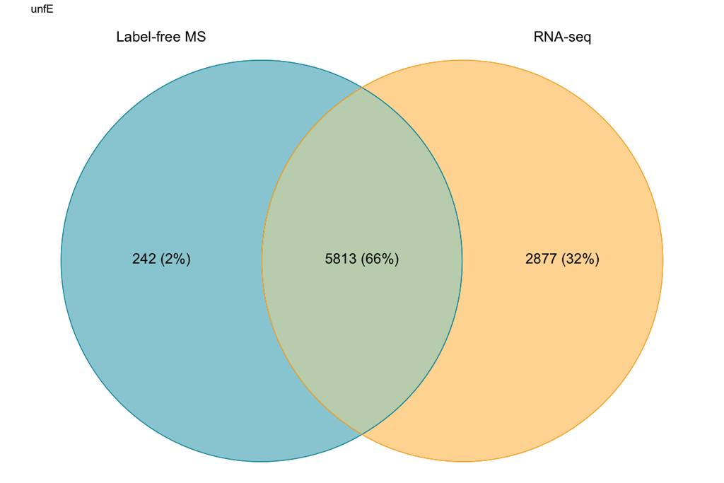

```r
colorGroups <- c("Label-free" = '#009baf', "RNA-seq" = '#ffb42c') # vector for colors
colfunc <- colorRampPalette(colorGroups) # use colorRampPalette to create function that interpolates colors
col <- colfunc(3) # call function and create vector of 3 colors

venn_overlap_egg.abs.rna <-
 ggplot() +
  geom_sf(aes(fill = name), data = venn_region(data)) +  # 1. region count layer
  geom_sf(aes(color = name), data = venn_setedge(data)) +  # 2. set edge layer
  # geom_sf(size = 4, lty = "dashed", color = "black", data = venn_setedge(data)) +
  geom_sf_text(aes(label = name), data = venn_setlabel(data), size = 6 ) +  # 3. set label layer
  geom_sf_text(aes(label = paste0(count," (", scales::percent(count/sum(count), accuracy = 2), ")")), data = venn_region(data),size = 6) +
  scale_fill_manual(values = alpha(col, .5)) +
  scale_color_manual(values = c("#009baf",'#ffb42c')) +
  labs(title = "unfE") +
  theme_void(base_family = "Arial") +
  theme(legend.position = "none")

venn_overlap_egg.abs.rna
```

```r
cairo_pdf("plot_overlap_prot_rna_unfE.pdf", width=8.5, height=5.6)
print(venn_overlap_egg.abs.rna)
invisible(dev.off())
```

## 1.4 Protein distribution - histogram

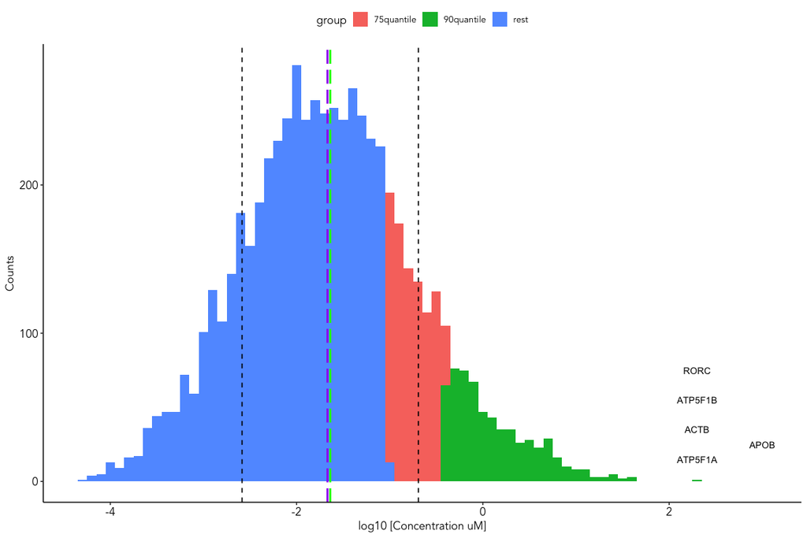

```r
###############################
#### stats
###############################
egg.abs_stat <-
  egg.abs %>%
  reframe(mean = mean(normalised_theil),
            median =median(normalised_theil),
            sd = sd(normalised_theil),
            enframe(quantile(normalised_theil, c(0,0.25, 0.5, 0.75,0.9,1)), "%", "quantile"))

#### Add annotation
egg.abs_ann.df <- left_join(egg.abs,annRef, by = c("gene_id" = "ky_gene_model"),keep =T)
#write.table(egg.abs_ann.df,file = "GF.unfertilised.eggs.df-KY21.txt", sep='\t', quote = F, col.names=T)

#### Add group column for quantile calculation
egg.abs_ann.df <- egg.abs_ann.df %>%
  arrange(desc(normalised_theil)) %>%
  mutate(rank = 1:nrow(egg.abs_ann.df),
         group = ifelse(egg.abs_ann.df$normalised_theil < 0.0905, 'rest', # below 75 quantile
                 ifelse(egg.abs_ann.df$normalised_theil > 0.383, '90quantile', '75quantile'))) %>%
  replace_na(list(gene.name =  "other"))

egg.abs_ann.df %>%
    filter(type== "TF" ) %>%   write.table(paste0(directory_figures,"egg.abs_ann_TF.tsv"), sep =" \t", col.names = T, row.names = F,quote = F)

egg.abs_ann.df %>%
    filter(type== "signalling" ) %>%  write.table(paste0(directory_figures,"egg.abs_ann_SMs.tsv"), sep =" \t", col.names = T, row.names = F,quote = F)

# quantiles distibution
egg.abs_ann.df %>%
  ggplot(aes(x = log10(normalised_theil), fill= group)) +
  geom_histogram(color=0, binwidth = 0.1) +
  geom_vline(aes(xintercept = mean(log10(normalised_theil))), linetype="longdash", color = "green", size = 1) +
  geom_vline(aes(xintercept = median(log10(normalised_theil))),linetype="longdash", color = "purple", size = 1) +
  geom_vline(aes(xintercept = mean(log10(normalised_theil)) + sd(log10(normalised_theil))), color = "#000000", size = 0.6, linetype = "dashed") +
  geom_vline(aes(xintercept = mean(log10(normalised_theil)) - sd(log10(normalised_theil))), color = "#000000", size = 0.6, linetype = "dashed") +
  annotate("text", x = 3, y = 25, label = "APOB", size = 3.5) +
  annotate("text", x = 2.3, y = 15, label = "ATP5F1A", size = 3.5) +
    annotate("text", x = 2.3, y = 35, label = "ACTB", size = 3.5) +
  annotate("text", x = 2.3, y = 55, label = "ATP5F1B", size = 3.5) +
  annotate("text", x = 2.3, y = 75, label = "RORC", size = 3.5) +
  xlab("log10 [Concentration uM]") +
  ylab("Counts") +
  theme_personalised
```

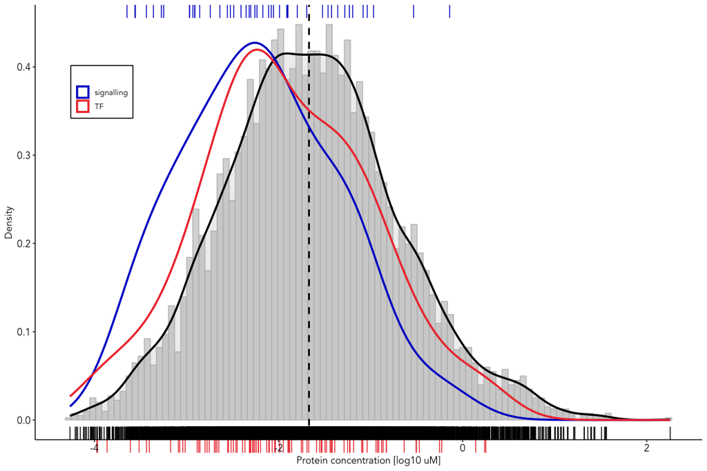

```r
###############################
#### density + histogram plot: global
###############################
plot_unfLF_density <- egg.abs_ann.df %>%
  ggplot(aes(x = log10(normalised_theil))) +
  geom_histogram(aes(y = ..density..),bins = 100,colour = "grey", fill = "grey",alpha=0.6) +
  geom_density(lwd = 1.2,linetype = 1, colour = "black", fill = "grey", alpha = 0.25) +
  geom_vline(aes(xintercept = median(log10(normalised_theil))), linetype= 2, color = "black", size = 1) +
  xlab("Protein concentration [log10 uM]") +
  ylab("Density") +
  geom_density(egg.abs_ann.df |>  drop_na() %>%
                 filter(type == "TF" | type == "signalling"),
                 # filter(type == "TF" | type == "ZF" | type == "signalling"),
                 # filter(type != "Pem/postplasmic RNA" & type != "NA"),
               mapping=aes(x = log10(normalised_theil), group=type,colour = type),
               lwd = 1.2,linetype = 1,  fill = NA, alpha = 0.85) +
  scale_color_manual(values = c(all = "grey55",TF = "brown2", ZF = "#e7298a", signalling = "mediumblue", Kinases = "#619cff", Phosphatases = "darkturquoise"),name="")+
  geom_rug() +
    coord_cartesian(clip = 'off') +
  geom_rug(data = . %>% filter(type == "TF"), color = "brown2", outside = T) +
  geom_rug(data = . %>% filter(type == "signalling"), sides = "t", color = "mediumblue", outside = F) +
  theme_personalised +
  theme(panel.spacing = unit(0.1, "lines"),
        strip.text.x = element_text(size = 8),
        legend.position = c(0.1, 0.8),
        legend.background = element_rect(fill = "white", color = "black"))
plot_unfLF_density
```

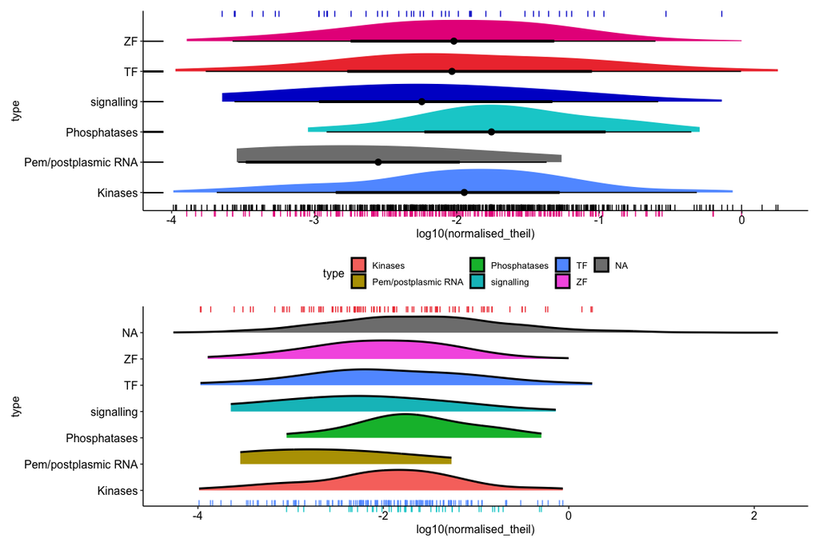

```r
###############################
#### adding other annotation
###############################
############### to fix later on: need to substitute NA so dropping them don't delate values
# egg.abs_ann.df_all = egg.abs_ann.df |>  mutate( type = "all")
# all_rowbind <- egg.abs_ann.df |> bind_rows(egg.abs_ann.df_all)
 # drop_na() %>%
  # filter(type != "Pem/postplasmic RNA" & type != "NA") %>%
  # mutate(type = factor(type,levels = c("TF", "ZF", "signalling","Kinases","Phosphatases"))) |>
  # mutate(type = factor(type,levels = c("Phosphatases", "Kinases", "signalling","ZF","TF"))) |>
a  <-
  egg.abs_ann.df %>%
  drop_na() |>
  ggplot(aes(y = type, x = log10(normalised_theil))) +
  stat_halfeye(aes(fill=type)) +
  labs(x = "log10(normalised_theil)", y = "type") +
  coord_cartesian(clip = 'off') +
  geom_rug() +
  geom_rug(data = . %>% filter(type == "ZF"), sides = "b", color = "#e7298a", outside = T) +
  geom_rug(data = . %>% filter(type == "signalling"), sides = "t", color = "mediumblue", outside = F) +
  scale_fill_manual(values = c(all = "grey55",TF = "brown2", ZF = "#e7298a", signalling = "mediumblue", Kinases = "#619cff", Phosphatases = "darkturquoise"))+
  theme_pubr(base_family = "Arial", legend = "none")

# to grab the extra rug plot
b <- egg.abs_ann.df %>%
  # drop_na() %>% filter(type != "Pem/postplasmic RNA" & type != "NA") %>% # to have the same xscale
  ggplot(aes(y = type, x = log10(normalised_theil))) +
  stat_slab(aes(fill=type), color = "black") +
  coord_cartesian(clip = 'off') +
  geom_rug(data = . %>% filter(type == "TF"), sides = "t", color = "brown2", outside = F) +
  geom_rug(data = . %>% filter(type == "Kinases"), sides = "b", color = "#619cff", outside = F) +
  geom_rug(data = . %>% filter(type == "Phosphatases"), sides = "b", color = "darkturquoise", outside = T)  +
  theme_pubr(base_family = "Arial")

a/b
```

## 1.5 Rank plot

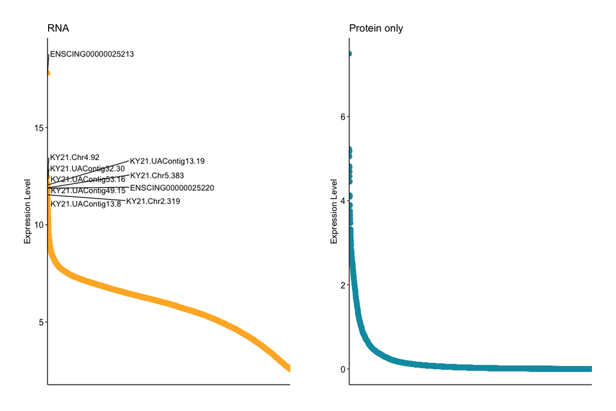

```r
###############################
#### Rank plot separate
###############################

rna_egg_rank <- rna_egg %>%
  mutate(abundance_rank = rank(unfE)) %>%
  arrange(desc(abundance_rank))

top_10_genes <- head(rna_egg_rank, 10)

RNA_rank_plot <-
  ggplot(rna_egg_rank, aes(x = fct_inorder(gene_id), y = log2(unfE+1))) +
  geom_point(size = 3, color= "#ffb42c") +
  labs(x = NULL, y = "Expression Level", title = "RNA") +
  ggrepel::geom_text_repel(data = top_10_genes, aes(label = gene_id), nudge_x = 4, nudge_y = 1) +
  theme_pubr() +
  theme(axis.text.x = element_blank(), axis.ticks.x = element_blank(),plot.margin = margin(1, 1, 1, 1, "cm"))

egg.abs_protein_rank <- egg.abs %>%
  mutate(normalised_theil=as.numeric(normalised_theil),
         abundance_rank = rank(normalised_theil),
         gene_id = as.factor(gene_id)) %>%
  arrange(desc(abundance_rank))

top_10_prot <- head(egg.abs_protein_rank, 20)

prot_rank_plot <-
  ggplot(egg.abs_protein_rank, aes(fct_reorder(protein_id,-normalised_theil), y = log2(normalised_theil+1))) +
  geom_point(size = 3, color= "#009baf") +
  labs(x = NULL, y = "Expression Level", title = "Protein only") +
  # ggrepel::geom_text_repel(data = top_10_prot, aes(label = gene_id), nudge_x = 1, nudge_y = 4) +
  theme_pubr() +
  theme(axis.text.x = element_blank(), axis.ticks.x = element_blank(),plot.margin = margin(1, 1, 1, 1, "cm"))

RNA_rank_plot + prot_rank_plot
```

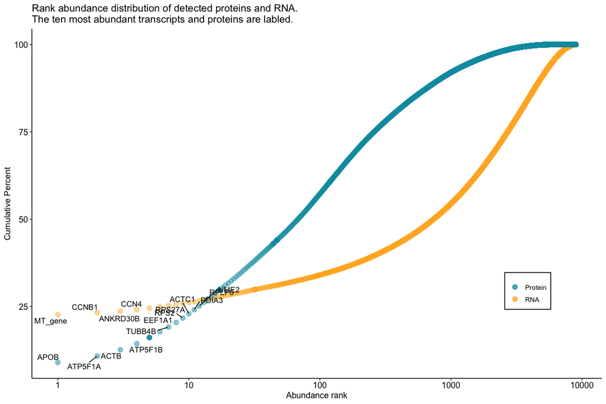

```r
###############################
#### rank all
###############################

df <- overlap_egg.abs.rna |>
  arrange(-unfE) |>
  mutate(rna_cumulative_percent = cumsum(unfE) / sum(unfE) * 100,
         rna_rank = row_number()) |>
  arrange(-normalised_theil) |>
  mutate(prot_cumulative_percent = cumsum(normalised_theil) / sum(normalised_theil) * 100,
         prot_rank = row_number()) |>
  relocate("protein_id","gene_id","normalised_theil","prot_rank","prot_cumulative_percent","unfE","rna_rank","rna_cumulative_percent")

annRef <-  annRef[,c(1,3,4,7)]
ann.df <- df |> left_join(annRef,by = c("gene_id"="ky_gene_model"))

annRef.gtf <- as_tibble(read_delim("/Users/mariossi/Library/CloudStorage/Dropbox-Princeton/Papers/Proteomics_ciona/a.reference_annotation/annotation_ciona.KY21.tsv",col_names = T,trim_ws = T))
annRef.gtf <- annRef.gtf[,c(1,9)] |>  distinct()

annRef.gtfMT <- as_tibble(read_delim("/Users/mariossi/Library/CloudStorage/Dropbox-Princeton/Papers/Proteomics_ciona/a.reference_annotation/annotation_ciona.KY21ensembl.109.MT.tsv",col_names = T,trim_ws = T))
annRef.gtfMT$HumanID <- ifelse(grepl("^ENSCINT", annRef.gtfMT$HumanID), "MT gene", annRef.gtfMT$HumanID)
annRef.gtfMT <- annRef.gtfMT[,c(1,10)] |>  distinct()

annRef_merged <- annRef.gtf |> full_join(annRef.gtfMT,by = c("GeneID"="GeneID"))

# annRef.gtf %>% write.table(paste0(directory_figures,"annRef.gtf.tsv"), sep =" \t", col.names = T, row.names = F,quote = F)
# annRef.gtfMT %>% write.table(paste0(directory_figures,"annRef.gtfMT.tsv"), sep =" \t", col.names = T, row.names = F,quote = F)
# annRef_merged %>% write.table(paste0(directory_figures,"annRef_merged.tsv"), sep =" \t", col.names = T, row.names = F,quote = F)

# genes blasted to multiple entries
corresponding_names <- annRef_merged %>%
  dplyr::select(GeneID, HumanID.x, HumanID.y) %>%
  mutate(Same_Name = ifelse(HumanID.x == HumanID.y, "Yes", "No")) |>
  mutate(unique_blast = ifelse(HumanID.x == HumanID.y, "unique_blast", "multiple_blast")) |>
  mutate(HumanID.x = ifelse(grepl("^Note=|^ORF", HumanID.x), HumanID.y, HumanID.x)) |>
  mutate(HumanID.x = ifelse(grepl("^ENSC", GeneID), "MT_gene", HumanID.x))

ann.df <- ann.df |>
  left_join(corresponding_names,by = c("gene_id"="GeneID"))
  # mutate(HumanID.x = ifelse(gene_id == "ENSCING00000025213", "MT_gene", HumanID.x)) # not workin

rows_to_update <- ann.df$gene_id == "ENSCING00000025213"
ann.df$HumanID.x[rows_to_update] <- "MT_gene"
colnames(ann.df)[colnames(ann.df) == "HumanID.x"] <- "HumanID"

top_15_gene <- ann.df %>%
  arrange(desc(unfE)) %>%
  slice_max(order_by = unfE, n = 15)

top_15_protein <- ann.df %>%
  arrange(desc(normalised_theil)) %>%
  slice_max(order_by = normalised_theil, n = 15)

ggplot(ann.df) +
  geom_point(aes(x = rna_rank, y = rna_cumulative_percent, color = "RNA"), size = 3, alpha =0.5) +
  geom_point(aes(x = prot_rank, y = prot_cumulative_percent, color = "Protein"), size = 3, alpha =0.5) +
  scale_x_continuous(trans='log10') +
  scale_color_manual(values = c("#009baf", "#ffb42c")) +
  labs(y="Cumulative Percent",x="Abundance rank",color = "") +
  ggtitle("Rank abundance distribution of detected proteins and RNA.
The ten most abundant transcripts and proteins are labled.") +
  theme_pubr(base_family = "Arial") +
  theme(legend.position = c(0.87, 0.25),
        legend.background = element_rect(fill = "white", color = "black"),
        legend.title=element_blank()) +
  geom_text_repel(
    data = top_15_gene,
    # aes(x = rna_rank, y =rna_cumulative_percent, label = gene_id),
    aes(x = rna_rank, y =rna_cumulative_percent, label = HumanID),
    # nudge_x = 0.2,
    # nudge_y = 0.1,
    # segment.size=0.5
  ) +
  geom_text_repel(
    data = top_15_protein,
    # aes(x = prot_rank, y = prot_cumulative_percent , label = gene_id),
    aes(x = prot_rank, y = prot_cumulative_percent , label = HumanID),
    # nudge_x = 0.2,
    # nudge_y = 0.2,
    # direction = "y",
    # segment.size=0.5
  )
```

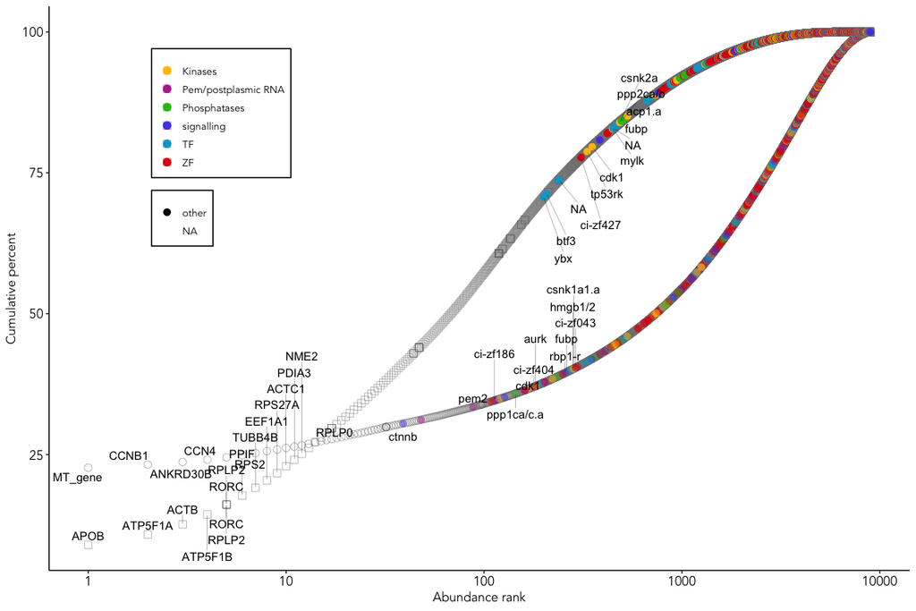

```r
###############################
#### overlaying maternal expression of transcription factor and signal transduction genes
###############################

all_egg_rna <-rna_egg |> right_join(annRef,by = c("gene_id"="ky_gene_model")) |>  drop_na() # 984 out of 1,389
TF_egg_rna <-rna_egg |> right_join(keyTF,by = c("gene_id"="ky_gene_model")) |>  drop_na() # 24 out of 318
SM_egg_rna <- rna_egg |> right_join(keySMs,by = c("gene_id"="ky_gene_model")) |>  drop_na() # 44 out of 130

all_egg_prot <- egg.abs.df |> right_join(annRef,by = c("gene_id"="ky_gene_model")) |>  drop_na() # 585 out of 1,389
TF_egg_prot <- egg.abs.df |> right_join(keyTF,by = c("gene_id"="ky_gene_model")) |>  drop_na() # 5 out of 318
SM_egg_prot <- egg.abs.df |> right_join(keySMs,by = c("gene_id"="ky_gene_model")) |>  drop_na() # 30 out of 130

all_TMT_prot <- ciona_prot.df |> right_join(annRef,by = c("protein_id_gene"="ky_gene_model")) |>  drop_na() # 729 out of 1,389
TF_TMT_prot <- ciona_prot.df |> right_join(keyTF,by = c("protein_id_gene"="ky_gene_model")) |>  drop_na() # 17 out of 318
SM_TMT_prot <- ciona_prot.df |> right_join(keySMs,by = c("protein_id_gene"="ky_gene_model")) |>  drop_na() # 40 out of 130

top_50_gene <- ann.df %>%
  arrange(desc(unfE)) %>%
  drop_na() |>
  distinct(gene_id, .keep_all = TRUE) %>%
  slice_max(order_by = unfE, n = 15)
top_50_gene %>% write.table(paste0(directory_figures,"top_50_geneTPM.tsv"), sep =" \t", col.names = T, row.names = F,quote = F)

top_50_protein <- ann.df %>%
  arrange(desc(normalised_theil)) %>%
  drop_na() %>%
  distinct(gene_id, .keep_all = TRUE) %>%
  slice_max(order_by = normalised_theil, n = 15)

top_50_protein %>% write.table(paste0(directory_figures,"top_50_protein.tsv"), sep =" \t", col.names = T, row.names = F,quote = F)

rankPlot <-
  ggplot(ann.df) +
  geom_point(aes(x = rna_rank, y = rna_cumulative_percent, color = "RNA"), shape=1,size = 3, alpha =0.5) +
  geom_point(aes(x = rna_rank, y = rna_cumulative_percent, color = type, shape = ifelse(type == "color_type", "color_type", "other")), size = 3, alpha = 0.5) +
  geom_point(aes(x = prot_rank, y = prot_cumulative_percent, color = "Protein"), shape=0,size = 3, alpha =0.5) +
  geom_point(aes(x = prot_rank, y = prot_cumulative_percent, color = type, shape = ifelse(type == "color_type", "color_type", "other")), size = 3, alpha = 1) +
  scale_x_continuous(trans = 'log10') +
  scale_color_manual(
    values = c(
      # "RNA" = "#ffb42c",
      # "Protein" ="#009baf",
      # "TF" = "brown2",
      # "ZF" = "#F9D14AFF",
      # "Kinases" = "#619cff",
      # "signalling" = "mediumblue",
      # "Phosphatases" = "darkturquoise",
      # "Pem/postplasmic RNA" = "#B43399" #

      "TF" ="#00A5CF",
      "ZF"="#DE1A1A",
      "signalling"="#574AE2",
      "Kinases"="#FFBF00",
      "Phosphatases" = "#29BF12",
      "Pem/postplasmic RNA" = "#B43399"
    )
    # na.value = "grey",
      ) +
  labs(y = "Cumulative percent", x = "Abundance rank", color = "Type") +
  # ggtitle("Rank abundance distribution of detected proteins and RNA.\nThe ten most abundant transcripts and proteins are labeled.\nThe ten most abundant TFs and SMs are labeled.") +
  theme_personalised +
  theme(
    legend.position = c(0.2, 0.75),
    legend.background = element_rect(fill = "white", color = "black"),
    legend.title = element_blank()
  ) +
  geom_text_repel(
    data = top_50_gene,
    aes(x = rna_rank, y = rna_cumulative_percent, label = gene_name),
    segment.size=0.1,
    direction = "y",
    vjust = 2
  ) +
  geom_text_repel(
    data = top_50_protein,
    aes(x = prot_rank, y = prot_cumulative_percent, label = gene_name),
        direction = "y",
    nudge_x = 0.1,
    segment.size=0.1
  ) +
  geom_text_repel(
    data = top_15_gene,
    aes(x = rna_rank, y =rna_cumulative_percent, label = HumanID)
  ) +
  geom_text_repel(
    data = top_15_protein,
    aes(x = prot_rank, y = prot_cumulative_percent , label = HumanID),
    direction = "y",
    nudge_y = 0.2,
    segment.size=0.1
  )
rankPlot
```

```r
cairo_pdf(paste0(directory_save,"plot_rankPlot.pdf"), width=8.5, height=5.6)
print(rankPlot)
invisible(dev.off())
```